# Hair Time

LKP & AR

2026-02-04

# 1 Initial note:

Figure 4A is derived from Dataset 1 (n = 4531). Figures 4B, 4C, 5A, and 5C are based on Dataset 2 (n = 3949), while Figure 5B is generated from Dataset 3 (n = 1450).  
Hairtime (pDLMO) distribution is consistent across all datasets. However, we re-plotted it to maintain a consistent structure across markdown sections and display the distribution of the sample from which each figure originates.

After merging datasets, some samples appeared more than once, resulting in duplicate records for the same ID. A systematic rule was applied to retain only one unique record per sample. For the sensitivity analysis, these duplicated entries were completely excluded from the dataset.

# 2 Figure 4A

## 2.1 Distribution - linear

```r
rm(list = ls(all = TRUE))

load("/Volumes/ALI_1TB/Projects/BodyTime/BodyTime_Final_Version/06_FinalDataset_2024/ht1.Rda")

dup <- read.csv("/Volumes/ALI_1TB/Projects/BodyTime/BodyTime_Final_Version_PNAS/06_FinalDataset/db_duplicate.csv")
colnames(dup) <- c("index", "duplicates")

# filter ht1 if ht2$id_s is in the dup$duplicates
ht1 <- ht1[!(ht1$id_s %in% dup$duplicates), ] # 3593

suppressMessages(library(ggplot2))
suppressMessages(library(tidyverse))

ht1$hair_time <- ifelse(ht1$hair_time > 13, ht1$hair_time -24, ht1$hair_time)

# plot

mean = mean(ht1$hair_time)
median = median(ht1$hair_time)
print(paste0("Mean of hairtime: ", mean(ht1$hair_time)))
```

```
## [1] "Mean of hairtime: -3.36344477962125"
```

```r
print(paste0("Median of hairtime: ", median(ht1$hair_time)))
```

```
## [1] "Median of hairtime: -3.51666666666667"
```

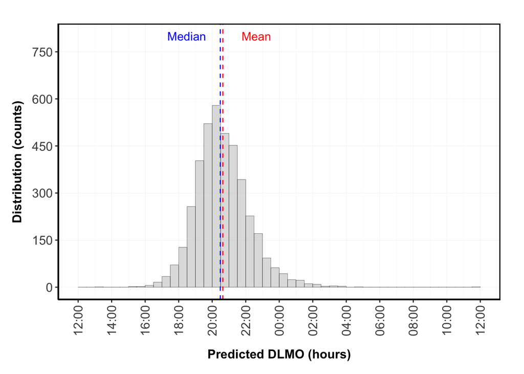

```r
distr <-
  ggplot() +
  geom_histogram(data = ht1, aes(x = hair_time),
                 fill = "grey", color = "black",
                 breaks = seq(-12,12,.5),
                 alpha = .5, linewidth = .1) +
  scale_y_continuous(name = "Distribution (counts)", breaks = seq(0, 900, 150)) +
  scale_x_continuous(limits = c(-12,12),
                     breaks = seq(-12,12,2),
                     labels = c("12:00","14:00", "16:00",
                                "18:00","20:00", "22:00",
                                "00:00",
                                "02:00", "04:00", "06:00",
                                "08:00", "10:00", "12:00"),
                     name = "Predicted DLMO (hours)") +
  geom_vline(xintercept = mean, color = "red", linetype = "dashed") +
  geom_vline(xintercept = median, color = "blue", linetype = "dashed") +
  # add annotation for vlines
  annotate("text", x = mean+2, y = 800, label = "Mean", color = "red", size = 4) +
  annotate("text", x = median-2, y = 800, label = "Median", color = "blue", size = 4) +
  theme_bw()+
  theme(plot.background = element_rect(fill = "transparent", colour = "transparent"),
        legend.position = "none",
        plot.margin = margin(.8, .8, .8, .6, "cm"),
        panel.border = element_rect(color = "black", fill = NA, linewidth = 1),
        axis.line =  element_line(),
        panel.grid.minor.y = element_blank(),
        panel.grid = element_line(linewidth = .1),
        axis.text = element_text(size = 12),
        axis.text.x = element_text(angle = 90, vjust = 0.5),
        axis.title = element_text(size = 12, face = "bold"),
        axis.title.x = element_text(vjust = -3),
        axis.title.y = element_text(vjust = 3))
distr
```

## 2.2 Distribution - Circular

```r
library(circular)
```

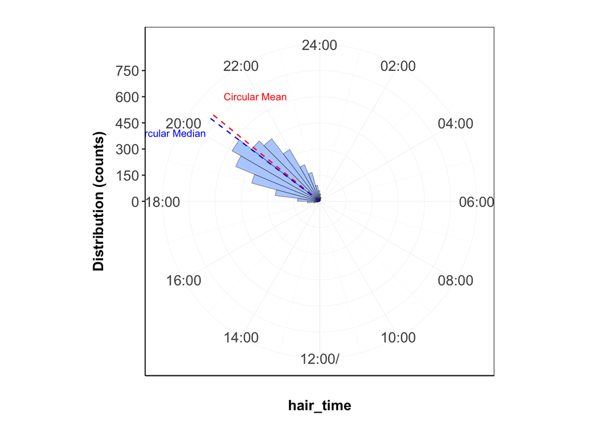

```r
library(ggplot2)

# Convert hair_time from hours to radians (for circular calculation)
ht_circular <- circular(ht1$hair_time * (2 * pi / 24), units = "radians", template = "clock24")

# Calculate circular mean and median
circular_mean_rad <- mean.circular(ht_circular)
circular_median_rad <- median.circular(ht_circular)

# Convert circular mean and median back to hours
circular_mean_hour <- as.numeric(circular_mean_rad) * (24 / (2 * pi))
circular_median_hour <- as.numeric(circular_median_rad) * (24 / (2 * pi))

# Adjust the plot code to include circular mean and median
distr <-
  ggplot() +
  geom_histogram(data = ht1, aes(x = hair_time),
                 fill = "#66a1ff", color = "black",
                 breaks = seq(-12, 12, 0.5),
                 alpha = 0.5, linewidth = 0.1) +
  geom_vline(xintercept = circular_mean_hour, color = "red", linetype = "dashed") +
  geom_vline(xintercept = circular_median_hour, color = "blue", linetype = "dashed") +
  annotate("text", x = circular_mean_hour + 0.5, y = 800,
           label = "Circular Mean", color = "red", size = 3, vjust = 0, hjust = 0) +
  annotate("text", x = circular_median_hour - 0.5, y = 750,
           label = "Circular Median", color = "blue", size = 3, vjust = 0, hjust = 1) +
  scale_y_continuous(name = "Distribution (counts)", breaks = seq(0, 900, 150)) +
  scale_x_continuous(limits = c(-12, 12),
                     breaks = seq(-12, 12, 2),
                     labels = c("12:00", "14:00", "16:00",
                                "18:00", "20:00", "22:00",
                                "24:00", "02:00", "04:00", "06:00",
                                "08:00", "10:00", "")) +
  coord_polar(start = pi) +  # Use coord_polar instead of coord_radial
  theme_bw() +
  theme(plot.background = element_rect(fill = "transparent", colour = "transparent"),
        legend.position = "none",
        plot.margin = margin(0.8, 0.8, 0.8, 0.6, "cm"),
        panel.border = element_rect(color = "black", fill = NA, linewidth = 0.4),
        axis.line = element_line(linewidth = 0.4),
        panel.grid.minor.y = element_blank(),
        panel.grid = element_line(linewidth = 0.1),
        axis.text = element_text(size = 12),
        axis.text.x = element_text(vjust = 0.5),
        axis.title = element_text(size = 12, face = "bold"),
        axis.title.x = element_text(vjust = -3),
        axis.title.y = element_text(vjust = 3))

distr
```

# 3 Figure 4B

## 3.1 Distribution

```r
rm(list = ls(all = TRUE))
load("/Volumes/ALI_1TB/Projects/BodyTime/BodyTime_Final_Version/06_FinalDataset_2024/ht2.Rda")

dup <- read.csv("/Volumes/ALI_1TB/Projects/BodyTime/BodyTime_Final_Version_PNAS/06_FinalDataset/db_duplicate.csv") # 3949
colnames(dup) <- c("index", "duplicates")

# filter ht2 if ht2$id_s is in the dup$duplicates
ht2 <- ht2[!(ht2$id_s %in% dup$duplicates), ] # 3593
3949 - 3593
```

```
## [1] 356
```

```r
library(ggplot2)
library(tidyverse)
library(dplyr)

# hair time around midnight
ht2$hair_time <- ifelse(ht2$hair_time > 13, ht2$hair_time -24, ht2$hair_time)

ht2$age_cat_label <- cut(ht2$age, breaks = seq(17,91,3), labels = seq(19, 90, 3))
ht2$age_cat_label <- as.numeric(as.character(ht2$age_cat_label))
ht2$age_cat_label[ht2$age_cat_label == 70] <- 68
ht2$age_cat_label[ht2$age_cat_label == 67] <- 68


ht2$age_cat <- cut(ht2$age, seq(17,71, 3))
ht2$age_cat <- as.character(ht2$age_cat)
ht2$age_cat[ht2$age_cat == "(68,71]"] <- "(65,70]"
ht2$age_cat[ht2$age_cat == "(65,68]"] <- "(65,70]"

# get dots
means <- ht2 %>% group_by(age_cat_label) %>% summarise(mean_age = mean(age),
                                                       se_hair_time = plotrix::std.error(hair_time),
                                                       mean_hair_time = mean(hair_time),
                                                       n = n())

means$x <- as.numeric(as.character(means$age_cat_label))
means <- means %>% rename(hair_time = mean_hair_time)


# first linear histogram to show distribution used to model (ht2)
mean = mean(ht2$hair_time)
median = median(ht2$hair_time)

print(paste0("Mean of hairtime: ", mean(ht2$hair_time)))
```

```
## [1] "Mean of hairtime: -3.35257445032007"
```

```r
print(paste0("Median of hairtime: ", median(ht2$hair_time)))
```

```
## [1] "Median of hairtime: -3.5"
```

```r
distr2 <-
  ggplot(ht2) +
  geom_histogram(data = ht2, aes(x = hair_time),
                 fill = "grey", color = "black",
                 breaks = seq(-12,12,.5),
                 alpha = .5, linewidth = .1) +
  theme_bw() +
  scale_y_continuous(name = "Distribution (counts)",
                     breaks = seq(0, 500, 100)) +
  scale_x_continuous(limits = c(-12,12),
                     breaks = seq(-12,12,2),
                     labels = c("12:00","14:00", "16:00",
                                "18:00","20:00", "22:00",
                                "00:00",
                                "02:00", "04:00", "06:00",
                                "08:00", "10:00", "12:00"),
                     name = "Predicted DLMO (hours)") +
  geom_vline(xintercept = mean, color = "red", linetype = "dashed") +
  geom_vline(xintercept = median, color = "blue", linetype = "dashed") +
  # add annotation for vlines
  annotate("text", x = mean+1, y = 800, label = "Mean", color = "red", size = 3) +
  annotate("text", x = median-1, y = 800, label = "Median", color = "blue", size = 3) +
  theme_bw()+
  theme(plot.background = element_rect(fill = "transparent", colour = "transparent"),
        legend.position = "none",
        plot.margin = margin(.8, .8, .8, .6, "cm"),
        panel.border = element_rect(color = "black", fill = NA, linewidth = 1),  # Add this line
        axis.line =  element_blank(),
        panel.grid.minor.y = element_blank(),
        panel.grid = element_line(linewidth = .1),
        axis.text = element_text(size = 12),
        axis.text.x = element_text(angle = 90, vjust = 0.5),
        axis.title = element_text(size = 12, face = "bold"),
        axis.title.x = element_text(vjust = -3),
        axis.title.y = element_text(vjust = 3))
distr2
```

[output not shown]

## 3.2 Association between variables

### 3.2.1 Tests

```r
suppressMessages(library(circular))
suppressMessages(library(CircStats))
suppressMessages(library(dplyr))
suppressMessages(library(Directional))
suppressMessages(library(car))

# Perform correlation test
corr <- cor.test(log(ht2$age), ht2$hair_time)
corr
```

```
##
##  Pearson's product-moment correlation
##
## data:  log(ht2$age) and ht2$hair_time
## t = -13.587, df = 3591, p-value < 2.2e-16
## alternative hypothesis: true correlation is not equal to 0
## 95 percent confidence interval:
##  -0.2520043 -0.1897992
## sample estimates:
##        cor
## -0.2211266
```

```r
# Perform t-test ==> robustness check with equal and unequal variances
median(ht2$age)
```

```
## [1] 37
```

```r
ht2$age_group <- ifelse(ht2$age < median(ht2$age), "young", "old")

print(t.test(ht2$hair_time ~ ht2$age_group, var.equal = F))
```

```
##
##  Welch Two Sample t-test
##
## data:  ht2$hair_time by ht2$age_group
## t = -12.043, df = 3538, p-value < 2.2e-16
## alternative hypothesis: true difference in means between group old and group young is not equal to 0
## 95 percent confidence interval:
##  -0.7258310 -0.5225877
## sample estimates:
##   mean in group old mean in group young
##           -3.657296           -3.033086
```

```r
print(t.test(ht2$hair_time ~ ht2$age_group, var.equal = T))
```

```
##
##  Two Sample t-test
##
## data:  ht2$hair_time by ht2$age_group
## t = -12.065, df = 3591, p-value < 2.2e-16
## alternative hypothesis: true difference in means between group old and group young is not equal to 0
## 95 percent confidence interval:
##  -0.7256499 -0.5227688
## sample estimates:
##   mean in group old mean in group young
##           -3.657296           -3.033086
```

### 3.2.2 Sensitivity analysis (circular analysis of pDLMO)

**Circular-linear correlation**

```r
suppressMessages(library(circular))
suppressMessages(library(CircStats))
suppressMessages(library(dplyr))
suppressMessages(library(Directional))

# Define younger and older groups based on median age
median_age <- median(ht2$age, na.rm = TRUE)
ht2$age_group <- ifelse(ht2$age < median_age, "young", "old")

# Extract numeric vectors for young and old
young <- ht2 %>% filter(age_group == "young") %>% pull(hair_time)
old <- ht2 %>% filter(age_group == "old") %>% pull(hair_time)
all <- ht2  %>% pull(hair_time)

# Convert hours to radians (since 24 hours = 2π radians)
young_rad <- young * (2 * pi / 24)
old_rad <- old * (2 * pi / 24)
all_rad <- all * (2 * pi / 24)

# Ensure all values are within [0, 2π]
young_rad <- (young_rad + 2 * pi) %% (2 * pi)
old_rad <- (old_rad + 2 * pi) %% (2 * pi)
all_rad <- (all_rad + 2 * pi) %% (2 * pi)

# Convert to circular data
young_circ <- circular(young_rad, units = "radians")
old_circ <- circular(old_rad, units = "radians")
all_circ <- circular(all_rad, units = "radians")

# 1. Linear circular correlation
circlin.cor(theta = all_circ, x = ht2$age, rads = TRUE)
```

```
##       R-squared      p-value
## [1,] 0.04363605 8.376383e-69
```

```r
# 1. Perform Watson-Williams test for homogeneity of means
ww_test <- watson.williams.test(list(young_circ, old_circ))
print(ww_test)
```

```
##
##  Watson-Williams test for homogeneity of means
##
## data:  1 and 2
## F = 146.78, df1 = 1, df2 = 3591, p-value < 2.2e-16
## sample estimates:
## Circular Data:
## Type = angles
## Units = radians
## Template = none
## Modulo = asis
## Zero = 0
## Rotation = counter
##  mean of 1  mean of 2
## -0.8009976 -0.9623371
```

```r
# 2. Non-parametric alternative (circular)
watson_wheeler_test <- watson.wheeler.test(list(young_circ, old_circ))
print(watson_wheeler_test)
```

```
##
##  Watson-Wheeler test for homogeneity of angles
##
## data:  1 and 2
## W = 87.981, df = 2, p-value < 2.2e-16
```

```r
# 3. Convert circular mean differences back to hours for interpretability
young_mean <- mean.circular(young_circ)
old_mean <- mean.circular(old_circ)

# Convert circular means from radians to hours
young_time <- (young_mean * 12 / pi) + 24
old_time <- (old_mean * 12 / pi) + 24

# Calculate the difference in minutes
time_diff_minutes <- (young_time - old_time) * 60
print(paste("Time difference between young and old groups (minutes):", round(time_diff_minutes, 2)))
```

```
## [1] "Time difference between young and old groups (minutes): 36.98"
```

## 3.3 Models

### 3.3.1 Regression (model A)

```r
library(splines)
m1 <- lm(hair_time ~  sex + age, data = ht2)
m2 <- lm(hair_time ~  sex + bs(age), data = ht2)

jtools::summ(m1, digits = 3, confint = T)
```

| Observations | 3593 |
| --- | --- |
| Dependent variable | hair_time |
| Type | OLS linear regression |

| F(2,3590) | 79.725 |
| --- | --- |
| R² | 0.043 |
| Adj. R² | 0.042 |

|  | Est. | 2.5% | 97.5% | t val. | p |
| --- | --- | --- | --- | --- | --- |
| (Intercept) | -2.366 | -2.528 | -2.204 | -28.641 | 0.000 |
| sexF | -0.109 | -0.214 | -0.005 | -2.049 | 0.041 |
| age | -0.023 | -0.027 | -0.019 | -11.571 | 0.000 |

Standard errors: OLS

```r
jtools::summ(m2, digits = 3, confint = T)
```

| Observations | 3593 |
| --- | --- |
| Dependent variable | hair_time |
| Type | OLS linear regression |

| F(4,3588) | 56.286 |
| --- | --- |
| R² | 0.059 |
| Adj. R² | 0.058 |

|  | Est. | 2.5% | 97.5% | t val. | p |
| --- | --- | --- | --- | --- | --- |
| (Intercept) | -2.258 | -2.491 | -2.025 | -19.020 | 0.000 |
| sexF | -0.087 | -0.191 | 0.017 | -1.634 | 0.102 |
| bs(age)1 | -1.509 | -2.150 | -0.867 | -4.612 | 0.000 |
| bs(age)2 | -1.801 | -2.228 | -1.374 | -8.266 | 0.000 |
| bs(age)3 | -1.055 | -1.502 | -0.608 | -4.626 | 0.000 |

Standard errors: OLS

#### 3.3.1.1 BIC:

```r
print(paste0("BIC for model 1 (age linear): ", BIC(m1)))
```

```
## [1] "BIC for model 1 (age linear): 13364.1917039724"
```

```r
print(paste0("BIC for model 2 (age splines): ", BIC(m2)))
```

```
## [1] "BIC for model 2 (age splines): 13318.0384523849"
```

```r
print("Selected: model 2")
```

```
## [1] "Selected: model 2"
```

### 3.3.2 Model assumptions

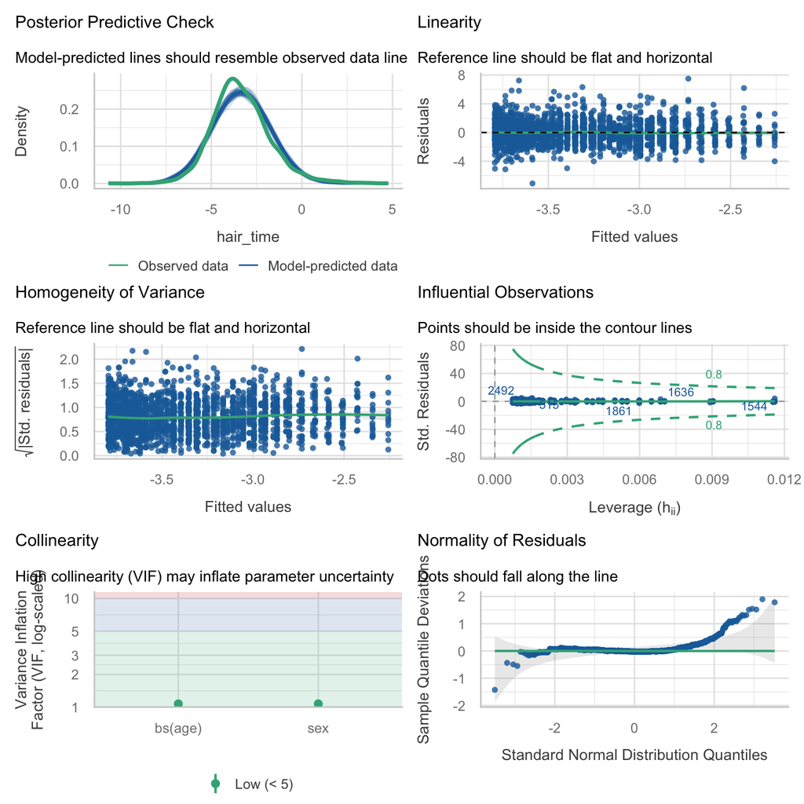

```r
suppressMessages(library(performance))
check_model(m2)
```

### 3.3.3 Plot

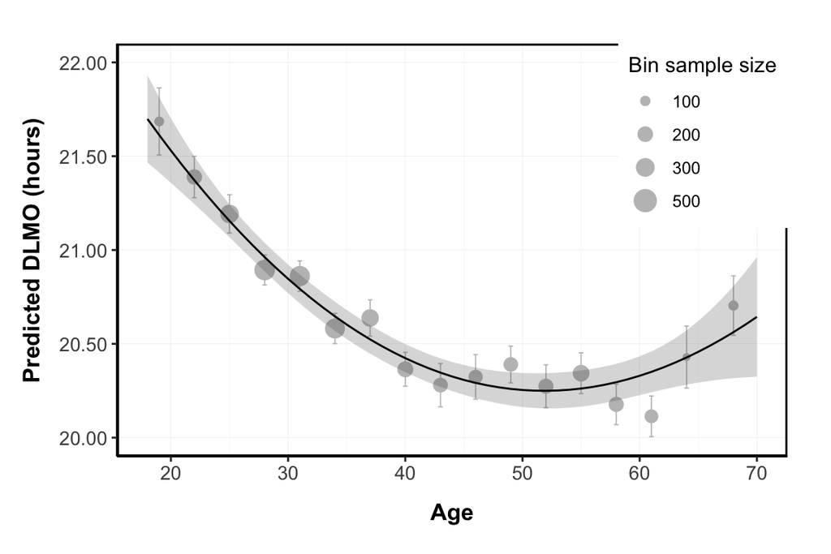

```r
library(ggplot2)
# get lines ----------------------------------------------------

eff_age <- ggeffects::predict_response(m2, margin = "marginalmeans", terms = "age")
eff_sex <- ggeffects::predict_response(m2, margin = "marginalmeans", terms = "sex")
eff <- ggeffects::predict_response(m2, margin = "marginalmeans", terms = c("age", "sex"))
eff <- eff %>% rename(hair_time = predicted)
eff_age <- eff_age %>% rename(hair_time = predicted)


# get dots ----------------------------------------------------

ht2$age_cat_label <- cut(ht2$age, breaks = seq(17,91,3),
                         labels = seq(19, 90, 3))
ht2$age_cat_label <- as.numeric(as.character(ht2$age_cat_label))
ht2$age_cat_label[ht2$age_cat_label == 70] <- 68
ht2$age_cat_label[ht2$age_cat_label == 67] <- 68


ht2$age_cat <- cut(ht2$age, seq(17,71, 3))

ht2$age_cat <- as.character(ht2$age_cat)
ht2$age_cat[ht2$age_cat == "(68,71]"] <- "(65,70]"
ht2$age_cat[ht2$age_cat == "(65,68]"] <- "(65,70]"

# get dots
means <- ht2 %>% group_by(age_cat_label) %>% summarise(mean_age = mean(age),
                                                        se_hair_time = plotrix::std.error(hair_time),
                                                        mean_hair_time = mean(hair_time),
                                                        n = n())

means$x <- as.numeric(as.character(means$age_cat_label))
means <- means %>% rename(hair_time = mean_hair_time)

as_distr <-
  ggplot() +
  geom_point(data = means, aes(x = x,
                               y = hair_time,
                               size = n),
             color = "grey75") +
  geom_errorbar(data = means, aes(x = x,
                                  ymin = hair_time-se_hair_time,
                                  ymax = hair_time+se_hair_time),
                linewidth = .3, width = .4, color = "grey75") +
  geom_line(data = eff_age, aes(x = x, y = hair_time)) +
  geom_ribbon(data = eff_age, aes(ymin = conf.low,
                                  ymax = conf.high,
                                  x = x), alpha = .2) +
  theme_bw() +
  scale_x_continuous(name = "Age", breaks = seq(20, 80, 10)) +
  scale_y_continuous("Predicted DLMO (hours)",
                     breaks = c(-4,-3.5,-3, -2.5, -2),
                     labels = c("20.00", "20.50",
                                "21.00", "21.50", "22.00"),
                     limits = c(-4, -2)) +
  theme(plot.background = element_rect(fill = "transparent", colour = "transparent"),
        plot.margin = margin(.8, .8, .8, .6, "cm"),
        panel.border = element_rect(color = "black", fill = NA, linewidth = 1),
        axis.line =  element_line(),
        panel.grid.minor.y = element_blank(),
        panel.grid = element_line(linewidth = .1),
        axis.text = element_text(size = 10),
        axis.title = element_text(size = 12, face = "bold"),
        axis.title.x = element_text(vjust = -2),
        axis.title.y = element_text(vjust = 3),
        legend.position = c(1, 1),
        legend.justification = c(1, 1)) +
  scale_size(name = "Bin sample size",
             limits = c(80, 500), range = c(1,5),
             breaks = c(100, 200, 300, 500))

as_distr
```

### 3.3.4 Sensitivity analysis (circular analysis of pDLMO):

**Regression using sine and cosine components**

```r
#rm(list = ls(all = TRUE))
load("/Volumes/ALI_1TB/Projects/BodyTime/BodyTime_Final_Version/06_FinalDataset_2024/ht2.Rda")

dup <- read.csv("/Volumes/ALI_1TB/Projects/BodyTime/BodyTime_Final_Version_PNAS/06_FinalDataset/db_duplicate.csv") # 3949
colnames(dup) <- c("index", "duplicates")

# filter ht2 if ht2$id_s is in the dup$duplicates
ht2 <- ht2[!(ht2$id_s %in% dup$duplicates), ] # 3593
3949 - 3593
```

```
## [1] 356
```

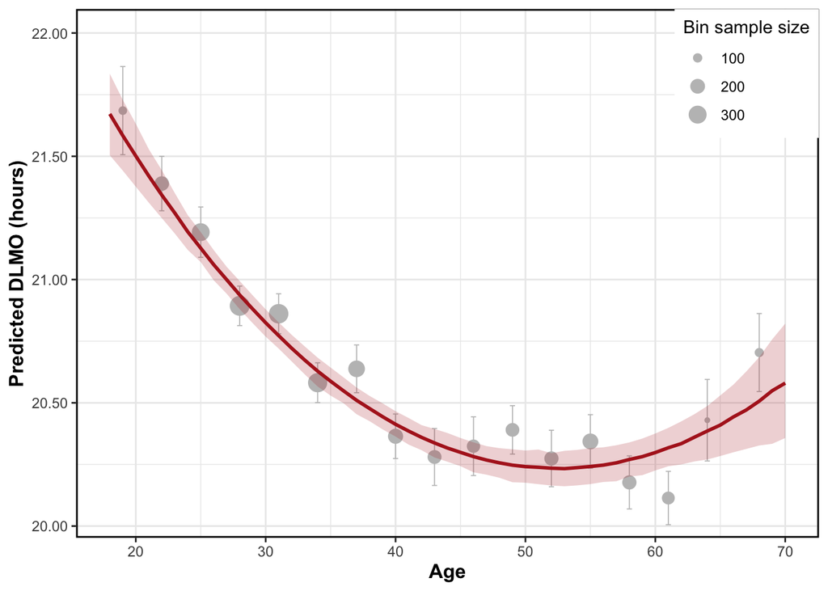

```r
library(dplyr)
library(ggplot2)
library(splines)
library(ggeffects) # The star of the show
library(plotrix)   # For std.error

# 1. Prepare Circular Data
# Convert time (0-24) to Angle -> Sine/Cosine
ht2$theta <- (ht2$hair_time %% 24) * (2*pi/24)
ht2$sin_t <- sin(ht2$theta)
ht2$cos_t <- cos(ht2$theta)

# 2. Fit the Two Component Models
# We use 'bs(age)' for the curve and 'sex' as a covariate
m_sin <- lm(sin_t ~ bs(age) + sex, data = ht2)
m_cos <- lm(cos_t ~ bs(age) + sex, data = ht2)


# Get Sine predictions
eff_sin <- predict_response(m_sin, terms = "age", margin = "marginalmeans")

# Get Cosine predictions
eff_cos <- predict_response(m_cos, terms = "age", margin = "marginalmeans")


# Helper function to approximate SE from 95% CI
get_se <- function(fit, upper) (upper - fit) / 1.96

# Create a clean dataframe for the simulation
sim_data <- data.frame(
  age = eff_sin$x,
  sin_fit = eff_sin$predicted,
  sin_se  = get_se(eff_sin$predicted, eff_sin$conf.high),
  cos_fit = eff_cos$predicted,
  cos_se  = get_se(eff_cos$predicted, eff_cos$conf.high)
)

# Run the simulation (vectorized for speed)
n_sims <- 1000
results <- list()

for(i in 1:nrow(sim_data)) {
  # 1. Simulate distributions for Sin and Cos
  s_sim <- rnorm(n_sims, sim_data$sin_fit[i], sim_data$sin_se[i])
  c_sim <- rnorm(n_sims, sim_data$cos_fit[i], sim_data$cos_se[i])

  # 2. Convert to Time
  angles <- atan2(s_sim, c_sim)
  times  <- (angles %% (2*pi)) * 24/(2*pi)

  # 3. Handle Midnight Wrap (centering on Noon)
  # If time < 12, add 24. This makes 01:00 become 25:00
  times_shifted <- ifelse(times < 12, times + 24, times)

  # 4. Store stats
  results[[i]] <- data.frame(
    x = sim_data$age[i],
    hair_time = mean(times_shifted),
    conf.low  = quantile(times_shifted, 0.025),
    conf.high = quantile(times_shifted, 0.975)
  )
}

# Bind results into one final prediction frame
eff_final <- do.call(rbind, results)

ht2$age_cat_label <- cut(ht2$age, breaks = seq(17,91,3), labels = seq(19, 90, 3))
ht2$age_cat_label <- as.numeric(as.character(ht2$age_cat_label))

# Fix outliers
ht2$age_cat_label[ht2$age_cat_label == 70] <- 68
ht2$age_cat_label[ht2$age_cat_label == 67] <- 68

# Shift Raw Data for Plotting (Noon to Noon)
ht2$hair_time_shifted <- ifelse(ht2$hair_time < 12, ht2$hair_time + 24, ht2$hair_time)

# Calculate Means
means <- ht2 %>%
  group_by(age_cat_label) %>%
  summarise(
    x = mean(age_cat_label),
    mean_hair_time = mean(hair_time_shifted, na.rm=TRUE),
    se_hair_time   = std.error(hair_time_shifted, na.rm=TRUE),
    n = n()
  ) %>%
  rename(hair_time = mean_hair_time)


ggplot() +
  # 1. Raw Data (Dots & Error Bars)
  geom_errorbar(data = means, aes(x = x,
                                  ymin = hair_time - se_hair_time,
                                  ymax = hair_time + se_hair_time),
                linewidth = 0.3, width = 0.4, color = "grey75") +

  geom_point(data = means, aes(x = x, y = hair_time, size = n),
             color = "grey75") +

  # 2. Model Prediction (Ribbon & Line from our Simulation)
  geom_ribbon(data = eff_final, aes(x = x, ymin = conf.low, ymax = conf.high),
              fill = "firebrick", alpha = 0.2) +

  geom_line(data = eff_final, aes(x = x, y = hair_time),
            color = "firebrick", linewidth = 1) +

  # 3. Styling
  theme_bw() +
  scale_x_continuous(name = "Age", breaks = seq(20, 80, 10)) +

  # Y-AXIS SCALE
  scale_y_continuous("Predicted DLMO (hours)",
                     breaks = c(20, 20.5, 21, 21.5, 22),
                     labels = c("20.00", "20.50", "21.00", "21.50", "22.00")) + # Close parenthesis here!

  # ZOOM LIMITS (Must be a separate layer)
  coord_cartesian(ylim = c(20.05, 22.0)) +

  theme(
    plot.background = element_rect(fill = "transparent", colour = NA),
    panel.border = element_rect(color = "black", fill = NA, linewidth = 1),
    axis.title = element_text(size = 12, face = "bold"),
    legend.position = c(1, 1),
    legend.justification = c(1, 1)
  ) +

  scale_size(name = "Bin sample size", range = c(1, 5))
```

# 4 Figure 4C

## 4.1 Distribution

```r
#rm(list = ls(all = TRUE))
load("/Volumes/ALI_1TB/Projects/BodyTime/BodyTime_Final_Version/06_FinalDataset_2024/ht2.Rda")

dup <- read.csv("/Volumes/ALI_1TB/Projects/BodyTime/BodyTime_Final_Version_PNAS/06_FinalDataset/db_duplicate.csv") # 3949
colnames(dup) <- c("index", "duplicates")

# filter ht2 if ht2$id_s is in the dup$duplicates
ht2 <- ht2[!(ht2$id_s %in% dup$duplicates), ] # 3593
3949 - 3593
```

```
## [1] 356
```

```r
library(ggplot2)
library(tidyverse)
library(dplyr)

# hair time around midnight
ht2$hair_time <- ifelse(ht2$hair_time > 13, ht2$hair_time -24, ht2$hair_time)

ht2$age_cat_label <- cut(ht2$age, breaks = seq(17,91,3), labels = seq(19, 90, 3))
ht2$age_cat_label <- as.numeric(as.character(ht2$age_cat_label))
ht2$age_cat_label[ht2$age_cat_label == 70] <- 68
ht2$age_cat_label[ht2$age_cat_label == 67] <- 68


ht2$age_cat <- cut(ht2$age, seq(17,71, 3))
ht2$age_cat <- as.character(ht2$age_cat)
ht2$age_cat[ht2$age_cat == "(68,71]"] <- "(65,70]"
ht2$age_cat[ht2$age_cat == "(65,68]"] <- "(65,70]"

# get dots
means <- ht2 %>% group_by(age_cat_label) %>% summarise(mean_age = mean(age),
                                                       se_hair_time = plotrix::std.error(hair_time),
                                                       mean_hair_time = mean(hair_time),
                                                       n = n())

means$x <- as.numeric(as.character(means$age_cat_label))
means <- means %>% rename(hair_time = mean_hair_time)

print(paste0("Mean of hairtime: ", mean(ht2$hair_time)))
```

```
## [1] "Mean of hairtime: -3.35257445032007"
```

```r
print(paste0("Median of hairtime: ", median(ht2$hair_time)))
```

```
## [1] "Median of hairtime: -3.5"
```

```r
# first linear histogram to show distribution used to model (ht2)
mean = mean(ht2$hair_time)
median = median(ht2$hair_time)
distr2 <-
  ggplot(ht2) +
  geom_histogram(data = ht2, aes(x = hair_time),
                 fill = "grey", color = "black",
                 breaks = seq(-12,12,.5),
                 alpha = .5, linewidth = .1) +
  theme_bw() +
  scale_y_continuous(name = "Distribution (counts)",
                     breaks = seq(0, 500, 100)) +
  scale_x_continuous(limits = c(-12,12),
                     breaks = seq(-12,12,2),
                     labels = c("12:00","14:00", "16:00",
                                "18:00","20:00", "22:00",
                                "00:00",
                                "02:00", "04:00", "06:00",
                                "08:00", "10:00", "12:00"),
                     name = "Predicted DLMO (hours)") +
  geom_vline(xintercept = mean, color = "red", linetype = "dashed") +
  geom_vline(xintercept = median, color = "blue", linetype = "dashed") +
  # add annotation for vlines
  annotate("text", x = mean+1, y = 800, label = "Mean", color = "red", size = 3) +
  annotate("text", x = median-1, y = 800, label = "Median", color = "blue", size = 3) +
  theme_bw()+
  theme(plot.background = element_rect(fill = "transparent", colour = "transparent"),
        legend.position = "none",
        plot.margin = margin(.8, .8, .8, .6, "cm"),
        panel.border = element_rect(color = "black", fill = NA, linewidth = 1),  # Add this line
        axis.line =  element_blank(),
        panel.grid.minor.y = element_blank(),
        panel.grid = element_line(linewidth = .1),
        axis.text = element_text(size = 12),
        axis.text.x = element_text(angle = 90, vjust = 0.5),
        axis.title = element_text(size = 12, face = "bold"),
        axis.title.x = element_text(vjust = -3),
        axis.title.y = element_text(vjust = 3))
distr2
```

[output not shown]

## 4.2 Comparing groups

### 4.2.1 Tests

```r
library(car)
# Extract numeric vectors for M and F
m <- ht2 %>% filter(sex == "M") %>% pull(hair_time)
f <- ht2 %>% filter(sex == "F") %>% pull(hair_time)

# Perform t-test ==> robustness check with equal and unequal variances
t_test = t.test(m, f, val.equal=F)
print(t_test)
```

```
##
##  Welch Two Sample t-test
##
## data:  m and f
## t = 4.9799, df = 3576.9, p-value = 6.662e-07
## alternative hypothesis: true difference in means is not equal to 0
## 95 percent confidence interval:
##  0.1585422 0.3644475
## sample estimates:
## mean of x mean of y
## -3.229360 -3.490854
```

```r
print(t.test(m, f, val.equal=T))
```

```
##
##  Welch Two Sample t-test
##
## data:  m and f
## t = 4.9799, df = 3576.9, p-value = 6.662e-07
## alternative hypothesis: true difference in means is not equal to 0
## 95 percent confidence interval:
##  0.1585422 0.3644475
## sample estimates:
## mean of x mean of y
## -3.229360 -3.490854
```

### 4.2.2 Plot

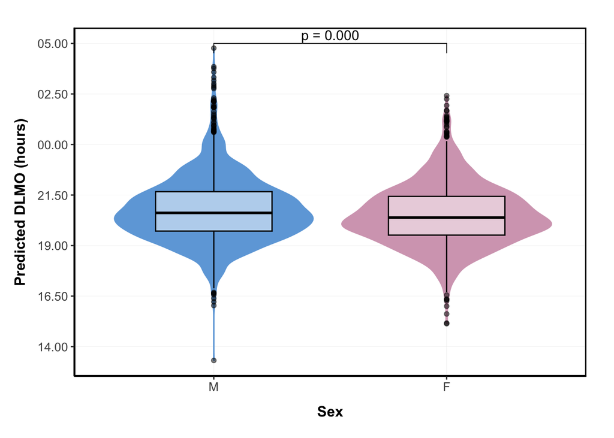

```r
library(ggpubr)

# Extract p-value
p_value_violin <- t_test$p.value

# Create violin plot
violin <- ggplot(ht2, aes(x = sex, y = hair_time)) +
  geom_violin(aes(color = sex, fill = sex)) +
  geom_boxplot(color = "black", alpha = .5, width = .5) +
  theme(legend.position = "none") +
  scale_color_manual(values = c("#6fa8dc", "#d5a6bd")) +
  scale_fill_manual(values = c("#6fa8dc", "#d5a6bd")) +
  xlab("Sex") +
  scale_y_continuous("Predicted DLMO (hours)",
                     breaks = c(-10, -7.5, -5, -2.5, 0, 2.5, 5.0),
                     labels = c("14.00", "16.50", "19.00", "21.50", "00.00", "02.50", "05.00"))  +
  theme_bw() +
  theme(plot.background = element_rect(fill = "transparent", colour = "transparent"),
        plot.margin = margin(.8, .8, .8, .6, "cm"),
        panel.border = element_rect(color = "black", fill = NA, linewidth = 1),
        legend.position = "none",
        axis.line = element_line(),
        panel.grid.minor.y = element_blank(),
        panel.grid = element_line(linewidth = .1),
        axis.text = element_text(size = 10),
        axis.title = element_text(size = 12, face = "bold"),
        axis.title.x = element_text(vjust = -2),
        axis.title.y = element_text(vjust = 3)) +
  stat_pvalue_manual(
    data = data.frame(group1 = "M", group2 = "F",
                      label = sprintf("p = %.3f", p_value_violin)),
    y.position = 5,
    size = 4
  )

violin
```

### 4.2.3 Sensitivity analysis (circular analysis of pDLMO)

**Watson-Williams test**

```r
# Convert hours to radians (since 24 hours = 2π radians)
m_rad <- m * (2 * pi / 24)
f_rad <- f * (2 * pi / 24)

# Ensure all values are within [0, 2π]
m_rad <- (m_rad + 2 * pi) %% (2 * pi)
f_rad <- (f_rad + 2 * pi) %% (2 * pi)

# Convert to circular data
m_circ <- circular(m_rad, units = "radians")
f_circ <- circular(f_rad, units = "radians")

# Perform Watson-Williams test
watson.williams.test(list(m_circ, f_circ))
```

```
##
##  Watson-Williams test for homogeneity of means
##
## data:  1 and 2
## F = 22.515, df1 = 1, df2 = 3591, p-value = 2.167e-06
## sample estimates:
## Circular Data:
## Type = angles
## Units = radians
## Template = none
## Modulo = asis
## Zero = 0
## Rotation = counter
##  mean of 1  mean of 2
## -0.8536555 -0.9180012
```

```r
print((-0.8551704 * 12 / 3.14159265359) + 24)
```

```
## [1] 20.73349
```

```r
print((-0.9232520 * 12 / 3.14159265359) + 24)
```

```
## [1] 20.47344
```

```r
print((((-0.8551704 * 12 / 3.14159265359) + 24)-((-0.9232520 * 12 / 3.14159265359) + 24)) * 60)
```

[output not shown]

## 4.3 Models

### 4.3.1 Regression (model A)

```r
# Build model
m1 <- lm(hair_time ~ sex + bs(age), data = ht2)
jtools::summ(m1, digits = 3, confint = T)
```

| Observations | 3593 |
| --- | --- |
| Dependent variable | hair_time |
| Type | OLS linear regression |

| F(4,3588) | 56.286 |
| --- | --- |
| R² | 0.059 |
| Adj. R² | 0.058 |

|  | Est. | 2.5% | 97.5% | t val. | p |
| --- | --- | --- | --- | --- | --- |
| (Intercept) | -2.258 | -2.491 | -2.025 | -19.020 | 0.000 |
| sexF | -0.087 | -0.191 | 0.017 | -1.634 | 0.102 |
| bs(age)1 | -1.509 | -2.150 | -0.867 | -4.612 | 0.000 |
| bs(age)2 | -1.801 | -2.228 | -1.374 | -8.266 | 0.000 |
| bs(age)3 | -1.055 | -1.502 | -0.608 | -4.626 | 0.000 |

Standard errors: OLS

### 4.3.2 Model assumptions

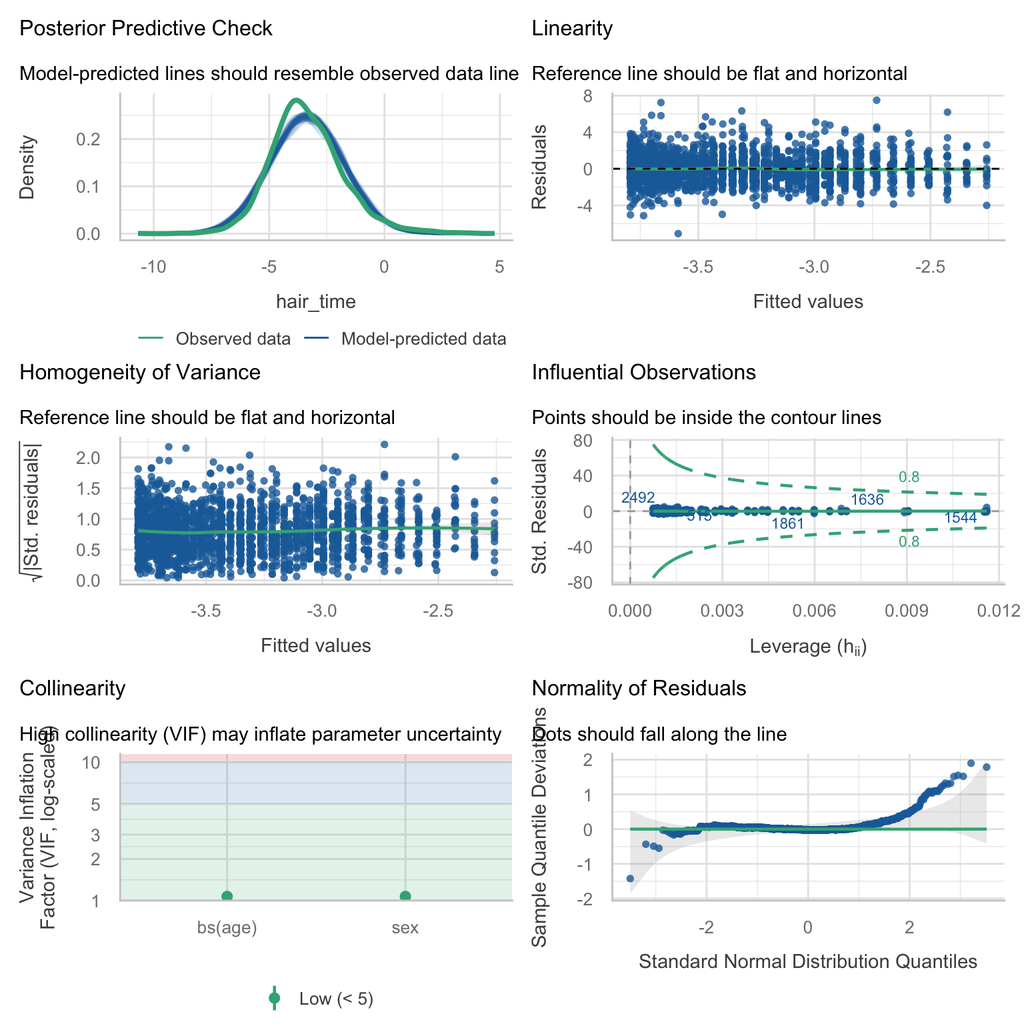

```r
suppressMessages(library(performance))
check_model(m1)
```

### 4.3.3 Plot (estimated marginal means)

```r
library(emmeans)
```

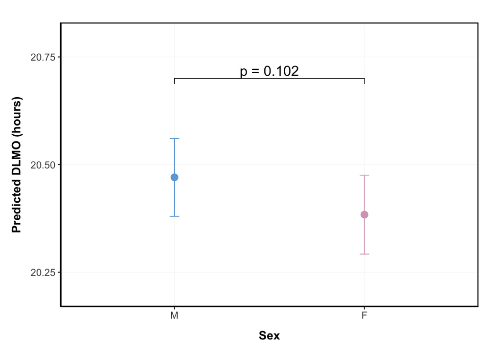

```r
library(ggpubr)

# Compute emmeans for pairwise comparisons
emmeans_results <- emmeans(m1, ~ sex)
pairwise_comparison <- contrast(emmeans_results, method = "pairwise")

# Extract p-value
p_value_sex <- summary(pairwise_comparison)$p.value

# Get effect estimates for sex
eff_sex <- ggeffects::predict_response(m1, margin = "marginalmeans", terms = "sex")

# Create mod_sex plot
mod_sex <- ggplot() +
  geom_point(data = eff_sex, aes(x = x, y = predicted, color = x), size = 3) +
  geom_errorbar(data = eff_sex, aes(x = x, ymin = conf.low, ymax = conf.high, color = x),
                linewidth = .4, width = .05) +
  theme_bw() +
  xlab("Sex") +
  scale_y_continuous("Predicted DLMO (hours)",
                     breaks = c(-4.00, -3.75, -3.5, -3.25, -3),
                     labels = c("19.00", "20.25", "20.50", "20.75", "21.00"),
                     limits = c(-3.8, -3.2)) +
  theme(plot.background = element_rect(fill = "transparent", colour = "transparent"),
        plot.margin = margin(.8, .8, .8, .6, "cm"),
        panel.border = element_rect(color = "black", fill = NA, linewidth = 1),
        legend.position = "none",
        axis.line = element_line(),
        panel.grid.minor.y = element_blank(),
        panel.grid = element_line(linewidth = .1),
        axis.text = element_text(size = 10),
        axis.title = element_text(size = 12, face = "bold"),
        axis.title.x = element_text(vjust = -2),
        axis.title.y = element_text(vjust = 3)) +
  scale_color_manual(values = c("#6fa8dc", "#d5a6bd"), name = "Working") +
  scale_fill_manual(values = c("#6fa8dc", "#d5a6bd"), name = "Working") +
  stat_pvalue_manual(
    data = data.frame(x = "F", y = 4.5, group1 = "M", group2 = "F",
                      label = sprintf("p = %.3f", p_value_sex)),
    y.position = -3.3,
    size = 5
  )

mod_sex
```

### 4.3.4 Sensitivity analysis (circular analysis of pDLMO)

**Regression using sine and cosine components**

```r
#rm(list = ls(all = TRUE))
load("/Volumes/ALI_1TB/Projects/BodyTime/BodyTime_Final_Version/06_FinalDataset_2024/ht2.Rda")

dup <- read.csv("/Volumes/ALI_1TB/Projects/BodyTime/BodyTime_Final_Version_PNAS/06_FinalDataset/db_duplicate.csv") # 3949
colnames(dup) <- c("index", "duplicates")

# filter ht2 if ht2$id_s is in the dup$duplicates
ht2 <- ht2[!(ht2$id_s %in% dup$duplicates), ] # 3593
3949 - 3593
```

```
## [1] 356
```

```r
library(dplyr)
library(ggplot2)
library(splines)
library(ggeffects)
library(ggpubr)
library(emmeans)

# hair time around midnight
ht2$hair_time <- ifelse(ht2$hair_time > 13, ht2$hair_time -24, ht2$hair_time)

# 1. Prepare Circular Data
# Convert time (0-24) to Angle -> Sine/Cosine
ht2$theta <- (ht2$hair_time %% 24) * (2*pi/24)
ht2$sin_t <- sin(ht2$theta)
ht2$cos_t <- cos(ht2$theta)

# 2. Fit the Two Component Models
m_sin <- lm(sin_t ~ bs(age) + sex, data = ht2)
m_cos <- lm(cos_t ~ bs(age) + sex, data = ht2)

# Get predictions for sex
eff_sin_sex <- predict_response(m_sin, terms = "sex", margin = "marginalmeans")
eff_cos_sex <- predict_response(m_cos, terms = "sex", margin = "marginalmeans")

# Helper function to approximate SE from 95% CI
get_se <- function(fit, upper) (upper - fit) / 1.96

# Create a clean dataframe for the simulation
sim_data_sex <- data.frame(
  sex = eff_sin_sex$x,
  sin_fit = eff_sin_sex$predicted,
  sin_se  = get_se(eff_sin_sex$predicted, eff_sin_sex$conf.high),
  cos_fit = eff_cos_sex$predicted,
  cos_se  = get_se(eff_cos_sex$predicted, eff_cos_sex$conf.high)
)

# Run the simulation
n_sims <- 1000
results_sex <- list()

for(i in 1:nrow(sim_data_sex)) {
  s_sim <- rnorm(n_sims, sim_data_sex$sin_fit[i], sim_data_sex$sin_se[i])
  c_sim <- rnorm(n_sims, sim_data_sex$cos_fit[i], sim_data_sex$cos_se[i])

  angles <- atan2(s_sim, c_sim)
  times  <- (angles %% (2*pi)) * 24/(2*pi)
  times_shifted <- ifelse(times < 12, times + 24, times)

  results_sex[[i]] <- data.frame(
    x = sim_data_sex$sex[i],
    hair_time = mean(times_shifted),
    conf.low  = quantile(times_shifted, 0.025),
    conf.high = quantile(times_shifted, 0.975)
  )
}

eff_sex_final <- do.call(rbind, results_sex)

# Compute p-value for circular model
# Test both sin and cos components jointly using Hotelling's T-squared approach
# Or use Wald test on both components
emmeans_sin <- emmeans(m_sin, ~ sex)
emmeans_cos <- emmeans(m_cos, ~ sex)

# Get p-values from both components
pairwise_sin <- contrast(emmeans_sin, method = "pairwise")
pairwise_cos <- contrast(emmeans_cos, method = "pairwise")

# For circular data, we need to test both components jointly
# Simple approach: use the more conservative (larger) p-value
p_value_sin <- summary(pairwise_sin)$p.value
p_value_cos <- summary(pairwise_cos)$p.value

# Use Bonferroni correction or take max (more conservative)
p_value_circular_sex <- max(p_value_sin, p_value_cos)

print(paste("Circular model - Sin component p-value:", p_value_sin))
```

```
## [1] "Circular model - Sin component p-value: 0.147983089565242"
```

```r
print(paste("Circular model - Cos component p-value:", p_value_cos))
```

```
## [1] "Circular model - Cos component p-value: 0.22637321812827"
```

```r
print(paste("Circular model - Combined p-value:", p_value_circular_sex))
```

```
## [1] "Circular model - Combined p-value: 0.22637321812827"
```

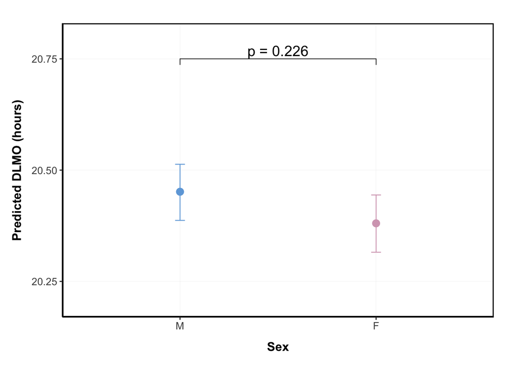

```r
# Create plot
mod_sex_circular <- ggplot() +
  geom_point(data = eff_sex_final, aes(x = x, y = hair_time, color = x), size = 3) +
  geom_errorbar(data = eff_sex_final, aes(x = x, ymin = conf.low, ymax = conf.high, color = x),
                linewidth = .4, width = .05) +
  theme_bw() +
  xlab("Sex") +
  scale_y_continuous("Predicted DLMO (hours)",
                     breaks = c(20.25, 20.5, 20.75),
                     labels = c("20.25", "20.50", "20.75")) +
  coord_cartesian(ylim = c(20.2, 20.8)) +
  theme(plot.background = element_rect(fill = "transparent", colour = "transparent"),
        plot.margin = margin(.8, .8, .8, .6, "cm"),
        panel.border = element_rect(color = "black", fill = NA, linewidth = 1),
        legend.position = "none",
        axis.line = element_line(),
        panel.grid.minor.y = element_blank(),
        panel.grid = element_line(linewidth = .1),
        axis.text = element_text(size = 10),
        axis.title = element_text(size = 12, face = "bold"),
        axis.title.x = element_text(vjust = -2),
        axis.title.y = element_text(vjust = 3)) +
  scale_color_manual(values = c("#6fa8dc", "#d5a6bd"), name = "Sex") +
  scale_fill_manual(values = c("#6fa8dc", "#d5a6bd"), name = "Sex") +
  stat_pvalue_manual(
    data = data.frame(x = "F", y = 4, group1 = "M", group2 = "F",
                      label = sprintf("p = %.3f", p_value_circular_sex)),
    y.position = 20.75,
    size = 5, tip_length = 0.02
  )


mod_sex_circular
```

# 5 Figure 5A

## 5.1 Distribution

```r
# Clear environment
#rm(list = ls(all = TRUE))

# Load dataset
load("/Volumes/ALI_1TB/Projects/BodyTime/BodyTime_Final_Version/06_FinalDataset_2024/ht2.Rda")

dup <- read.csv("/Volumes/ALI_1TB/Projects/BodyTime/BodyTime_Final_Version_PNAS/06_FinalDataset/db_duplicate.csv") # 3949
colnames(dup) <- c("index", "duplicates")

# filter ht2 if ht2$id_s is in the dup$duplicates
ht2 <- ht2[!(ht2$id_s %in% dup$duplicates), ] # 3593
3949 - 3593
```

```
## [1] 356
```

```r
# number of NA in ht2$employed
sum(is.na(ht2$employed))
```

```
## [1] 0
```

```r
ht2 <- ht2 %>% filter(!is.na(employed))

# Load required libraries
library(ggplot2)
library(tidyverse)
library(dplyr)
library(splines)
library(ggpubr)
library(emmeans)

# Adjust hair_time
ht2$hair_time <- ifelse(ht2$hair_time > 13, ht2$hair_time - 24, ht2$hair_time)

# linear histogram to show distribution used to model
# first linear histogram to show distribution used to model (ht2)
mean = mean(ht2$hair_time)
median = median(ht2$hair_time)

print(paste0("Mean of hairtime: ", mean(ht2$hair_time)))
```

```
## [1] "Mean of hairtime: -3.35257445032007"
```

```r
print(paste0("Median of hairtime: ", median(ht2$hair_time)))
```

```
## [1] "Median of hairtime: -3.5"
```

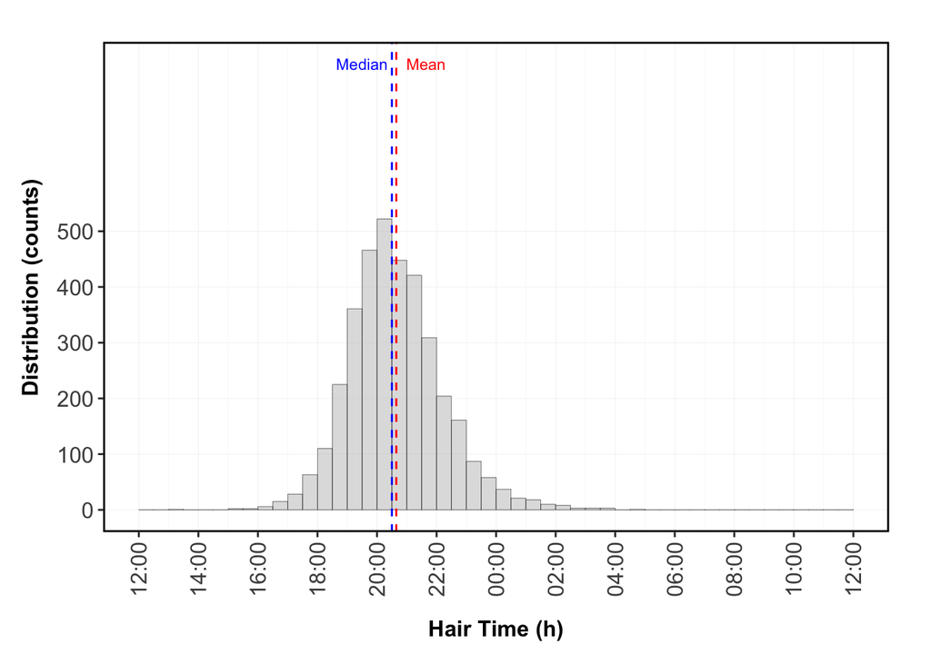

```r
distr2 <-
  ggplot(ht2) +
  geom_histogram(data = ht2, aes(x = hair_time),
                 fill = "grey", color = "black",
                 breaks = seq(-12,12,.5),
                 alpha = .5, linewidth = .1) +
  theme_bw() +
  scale_y_continuous(name = "Distribution (counts)",
                     breaks = seq(0, 500, 100)) +
  scale_x_continuous(limits = c(-12,12),
                     breaks = seq(-12,12,2),
                     labels = c("12:00","14:00", "16:00",
                                "18:00","20:00", "22:00",
                                "00:00",
                                "02:00", "04:00", "06:00",
                                "08:00", "10:00", "12:00"),
                     name = "Hair Time (h)") +
  geom_vline(xintercept = mean, color = "red", linetype = "dashed") +
  geom_vline(xintercept = median, color = "blue", linetype = "dashed") +
  # add annotation for vlines
  annotate("text", x = mean+1, y = 800, label = "Mean", color = "red", size = 3) +
  annotate("text", x = median-1, y = 800, label = "Median", color = "blue", size = 3) +
  theme_bw()+
  theme(plot.background = element_rect(fill = "transparent", colour = "transparent"),
        legend.position = "none",
        plot.margin = margin(.8, .8, .8, .6, "cm"),
        panel.border = element_rect(color = "black", fill = NA, linewidth = 1),  # Add this line
        axis.line =  element_blank(),
        panel.grid.minor.y = element_blank(),
        panel.grid = element_line(linewidth = .1),
        axis.text = element_text(size = 12),
        axis.text.x = element_text(angle = 90, vjust = 0.5),
        axis.title = element_text(size = 12, face = "bold"),
        axis.title.x = element_text(vjust = -3),
        axis.title.y = element_text(vjust = 3))
distr2
```

## 5.2 Comparing groups

### 5.2.1 Testing

```r
suppressMessages(library(circular))
suppressMessages(library(car))
# Extract numeric vectors for M and F
em <- ht2 %>% filter(employed == "Yes") %>% pull(hair_time)
nem <- ht2 %>% filter(employed == "No") %>% pull(hair_time)

# Perform t-test ==> robustness check with equal and unequal variances
t_test = t.test(em, nem, var.equal = F)
print(t_test)
```

```
##
##  Welch Two Sample t-test
##
## data:  em and nem
## t = -5.4909, df = 491.85, p-value = 6.42e-08
## alternative hypothesis: true difference in means is not equal to 0
## 95 percent confidence interval:
##  -0.6928695 -0.3276857
## sample estimates:
## mean of x mean of y
## -3.411087 -2.900809
```

```r
print(t.test(em, nem, var.equal = T))
```

```
##
##  Two Sample t-test
##
## data:  em and nem
## t = -6.1958, df = 3591, p-value = 6.456e-10
## alternative hypothesis: true difference in means is not equal to 0
## 95 percent confidence interval:
##  -0.6717528 -0.3488024
## sample estimates:
## mean of x mean of y
## -3.411087 -2.900809
```

### 5.2.2 Plot

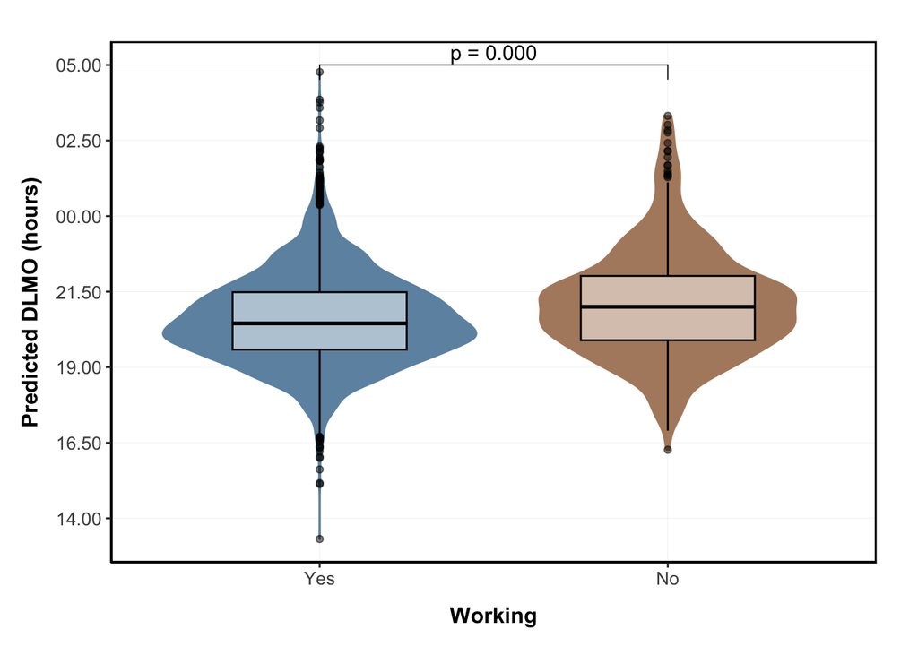

```r
# Extracting p-value
p_value_violin <- t_test$p.value
# Create violin plot
violin <- ggplot(ht2, aes(x = employed, y = hair_time)) +
  geom_violin(aes(color = employed, fill = employed)) +
  geom_boxplot(color = "black", alpha = .5, width = .5) +
  theme(legend.position = "none") +
  scale_color_manual(values = c("#6D93B0", "#B08A6D")) +
  scale_fill_manual(values = c("#6D93B0", "#B08A6D")) +
  xlab("Working") +
  scale_y_continuous("Predicted DLMO (hours)",
                     breaks = c(-10, -7.5, -5, -2.5, 0, 2.5, 5),
                     labels = c("14.00", "16.50", "19.00", "21.50", "00.00", "02.50", "05.00"))  +
  theme_bw() +
  theme(plot.background = element_rect(fill = "transparent", colour = "transparent"),
        plot.margin = margin(.8, .8, .8, .6, "cm"),
        panel.border = element_rect(color = "black", fill = NA, linewidth = 1),
        legend.position = "none",
        axis.line =  element_line(linewidth = .4),
        panel.grid.minor.y = element_blank(),
        panel.grid = element_line(linewidth = .1),
        axis.text = element_text(size = 10),
        axis.title = element_text(size = 12, face = "bold"),
        axis.title.x = element_text(vjust = -2),
        axis.title.y = element_text(vjust = 3)) +
  stat_pvalue_manual(
    data = data.frame(group1 = "No", group2 = "Yes",
                      label = sprintf("p = %.3f", p_value_violin)),
    y.position = 5,
    size = 4
  )
violin
```

### 5.2.3 Sensitivity analysis (circular analysis of pDLMO)

**Watson-Williams test**

```r
# Convert hours to radians (since 24 hours = 2π radians)
em_rad <- em * (2 * pi / 24)
nem_rad <- nem * (2 * pi / 24)

# Ensure all values are within [0, 2π]
em_rad <- (em_rad + 2 * pi) %% (2 * pi)
nem_rad <- (nem_rad + 2 * pi) %% (2 * pi)

# Convert to circular data
em_circ <- circular(em_rad, units = "radians")
nem_circ <- circular(nem_rad, units = "radians")

# Perform Watson-Williams test
watson.williams.test(list(em_circ, nem_circ))
```

```
##
##  Watson-Williams test for homogeneity of means
##
## data:  1 and 2
## F = 35.543, df1 = 1, df2 = 3591, p-value = 2.736e-09
## sample estimates:
## Circular Data:
## Type = angles
## Units = radians
## Template = none
## Modulo = asis
## Zero = 0
## Rotation = counter
##  mean of 1  mean of 2
## -0.8983614 -0.7704109
```

```r
# print((-0.8551704 * 12 / 3.14159265359) + 24)
# print((-0.9232520 * 12 / 3.14159265359) + 24)
#
# print((((-0.8551704 * 12 / 3.14159265359) + 24)-((-0.9232520 * 12 / 3.14159265359) + 24)) * 60)
```